# Rajiya_BatchC

```python
import tensorflow as tf
import numpy as np
import matplotlib.pyplot as plt
```

Importing dataset

```python
fashion_mnist = tf.keras.datasets.fashion_mnist
(train_images, train_labels), (test_images, test_labels) = fashion_mnist.load_data()
```

1. visualize few images from train and test set

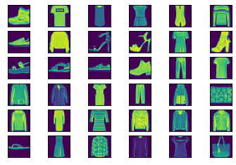

```python
for i in range(36):
    plt.subplot(6,6,i+1)
    plt.xticks([])
    plt.yticks([])
    plt.imshow(train_images[i])
plt.show()
```

[figure not shown]

```python
for i in range(25):
    plt.subplot(5,5,i+1)
    plt.xticks([])
    plt.yticks([])
    plt.imshow(test_images[i])
plt.show()
```

1. Build a feed-forward neural network model using following information

```python
print("train_iamges shape: ",train_images.shape)
print("train_labels shape: ",train_labels.shape)
print("test_images: ",test_images.shape)
print("test_labels: ",test_labels.shape)
```

```
train_iamges shape:  (60000, 28, 28)
train_labels shape:  (60000,)
test_images:  (10000, 28, 28)
test_labels:  (10000,)
```

```python
train_images = train_images.reshape(60000,784)
test_images = test_images.reshape(10000,784)
train_labels = train_labels.astype('float32')
test_labels = test_labels.astype('float32')
```

```python
train_images = train_images/255
test_images = test_images/255
```

```python
from keras.datasets import mnist
from keras.utils import np_utils
n_classes = 10
train_labels = np_utils.to_categorical(train_labels,n_classes)
test_labels = np_utils.to_categorical(test_labels,n_classes)
print(train_labels.shape)
print(test_labels.shape)
```

```
(60000, 10)
(10000, 10)
```

```python
from keras.models import Sequential
model = Sequential()
```

An input layer with appropriate number of neurons as per the data and First hidden layer with 64 neurons and relu activation

```python
from keras.layers import Dense
model.add(Dense(64,input_shape=(784,),activation='relu'))
```

Second hidden layer with 32 neurons and relu activation

```python
model.add(Dense(32,activation = 'relu'))
```

An output layer with suitable number of neurons, as per the problem requirements. Use suitable activation function as per the problem requirements

```python
model.add(Dense(10,activation = 'softmax'))
```

1. Display the summary of the model built. Give explanation on number of trainable/non-trainable parameters with the mathematical calculation of getting number of trainable/non-trainable parameters.

```python
model.summary()
```

```
Model: "sequential"
_________________________________________________________________
Layer (type)                 Output Shape              Param #
=================================================================
dense (Dense)                (None, 64)                50240
_________________________________________________________________
dense_1 (Dense)              (None, 32)                2080
_________________________________________________________________
dense_2 (Dense)              (None, 10)                330
=================================================================
Total params: 52,650
Trainable params: 52,650
Non-trainable params: 0
_________________________________________________________________
```

Trainable parameters are imput and hidden layers

input=784

hidden layer 1= 64 neurons

hidden layer 1= 32 neurons

output layer = 10 neurons

paramters = conection b/w layers + biases in every layer

parameter = ((784*64)+(64*32)+(32*10))+(64+32+10) = 52650

```python
model.compile(optimizer='adam',loss='categorical_crossentropy',metrics=['accuracy'])
```

1. Train the model on the training data, by taking validation set as 10% of training set.

```python
history=model.fit(train_images,train_labels, batch_size=128, epochs=10, validation_data=(test_images, test_labels), validation_split=0.10,verbose=1)
```

```
[0.43393903970718384, 0.3997621238231659, 0.38853445649147034, 0.3747435212135315, 0.3608403205871582, 0.34311527013778687, 0.33715707063674927, 0.340402752161026, 0.3375502824783325, 0.33823010325431824]
```

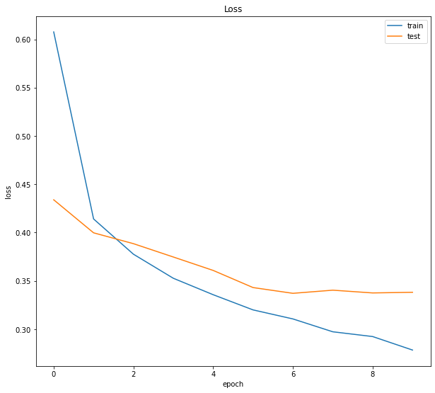

```python
print(history.history['val_loss'])
plt.figure(figsize=(10,20))
plt.subplot(211)
plt.title('Loss')
plt.plot(history.history['loss'],label='train')
plt.plot(history.history['val_loss'],label='test')
plt.xlabel('epoch')
plt.ylabel('loss')
plt.legend()
```

```
[0.8441666960716248, 0.8554999828338623, 0.8551666736602783, 0.8619999885559082, 0.8734999895095825, 0.8758333325386047, 0.8796666860580444, 0.8766666650772095, 0.8799999952316284, 0.8771666884422302]
```

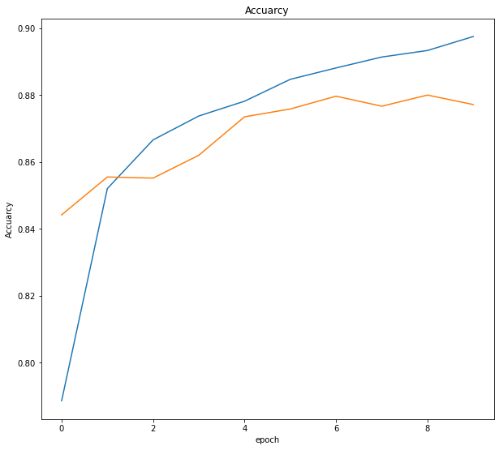

```python
print(history.history['val_accuracy'])
plt.figure(figsize=(10,20))
plt.subplot(212)
plt.title('Accuarcy')
plt.plot(history.history['accuracy'],label='train')
plt.plot(history.history['val_accuracy'],label='test')
plt.xlabel('epoch')
plt.ylabel('Accuarcy')
```

```python
from keras.callbacks import EarlyStopping
callbacks=EarlyStopping(monitor='val_accuracy',verbose=1,patience=3,mode='auto')
```

```python
history=model.fit(train_images,train_labels, batch_size=128, epochs=10, validation_data=(test_images, test_labels), validation_split=0.10,verbose=1,callbacks=[callbacks])
```

```
Epoch 00004: early stopping
```

```python
train_loss, train_acc = model.evaluate(train_images, train_labels, verbose=2)

print('accuracy:', train_acc)
```

```
1875/1875 - 1s - loss: 0.2660 - accuracy: 0.9016
accuracy: 0.9015833139419556
```